# Lecture 4 Biological enrichment calculations and GO/GSEA

04/06/2021

### Goals

- learn what qualifies as enrichment

### Goals

- learn what qualifies as enrichment
- learn various ways to calculate enrichment for different situations

### Goals

- learn what qualifies as enrichment
- learn various ways to calculate enrichment for different situations
- applications to annotations in RNA-seq data (i.e. GO)

### Goals

- learn what qualifies as enrichment
- learn various ways to calculate enrichment for different situations
- applications to annotations in RNA-seq data (i.e. GO)
- what are ontologies, and what are their limitations?

### Why enrichment?

We hear this term of art *constantly* throughout biology, molecular biology, genomics & especially bioinformatics.

### Why enrichment?

# ENRICHMENT IS **evidence for organized activity**

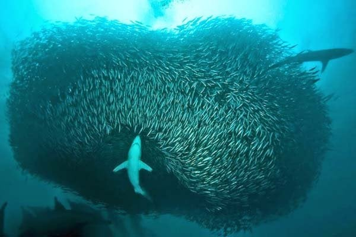

### What is enrichment?

more things than expected due to random chance

### What is enrichment?

more things than expected due to random chance

- what do you expect?

### Calculating enrichment

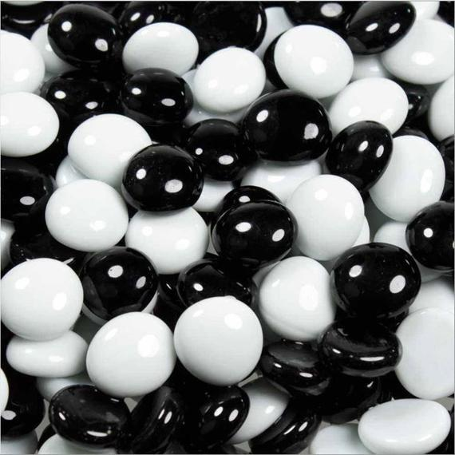

### Calculating enrichment

- finite number of marbles

### Calculating enrichment

- finite number of marbles
- known number of blacks & whites

### Calculating enrichment

- finite number of marbles
- known number of blacks & whites
- therefore probabilities are known

### Calculating enrichment

- finite number of marbles
- known number of blacks & whites
- therefore probabilities are known p_white, p_black

### Calculating enrichment

If we select a single marble, the probabilities change

m = 15, n = 45

### Calculating enrichment

If we select a single marble, the probabilities change

m = 15, n = 45

draw1: p_m = 15 / 15 + 45

```
[1] 0.25
```

### Calculating enrichment

If we select a single marble, the probabilities change

m = 15, n = 45

draw1: p_m = 15 / 15 + 45

```
[1] 0.25
```

draw2: p_m = 14 / 14 + 45

```
[1] 0.237
```

### Calculating enrichment

If we select multiple marbles, the probabilities are described by

# [Hypergeometric distribution](https://en.wikipedia.org/wiki/Hypergeometric_distribution)

### Calculating enrichment

If we select multiple marbles, the probabilities are described by

# [Hypergeometric distribution](https://en.wikipedia.org/wiki/Hypergeometric_distribution)

Hypergeo is related to binomial dist

- finite population
- sampling without replacement

### Calculating enrichment in R

Function `phyper`

```r
phyper(q, m, n, k, lower.tail = TRUE, log.p = FALSE)
```

- `q` vector of quantiles representing the number of white marbles drawn without replacement from a bag which contains both black and white marbles.
- `m` the number of white marbles in the bag
- `n` the number of black marbles in the bag
- `k` the number of marbles drawn

### Hypergeometric distribution

(PMF = “**P**robability **M**ass **F**unction)

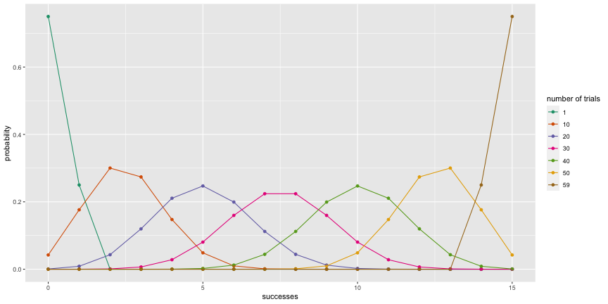

### Hypergeometric distribution

(PMF = “**P**robability **M**ass **F**unction)

```r
library("dplyr")
library("ggplot2")
library("foreach")
library("RColorBrewer")
##
x = 0:15
k = 0:60
pmfprobs <- foreach(i = x, .combine = 'rbind') %do% data.frame(x=rep(i, length(k)), k, p = dhyper(i, 15, 45, k))
ggplot(pmfprobs[pmfprobs$k %in% c(1, 10, 20, 30, 40, 50, 59),]) +
  geom_point(aes(x = x, y = p, colour = factor(k))) +
  geom_line(aes(x = x, y = p, colour = factor(k))) +
  scale_color_brewer(palette="Dark2", name = "number of trials") +
  ylab("probability") +
  xlab("successes")
  theme_minimal() +
  theme(text = element_text(size=24)) +
  ggtitle("Probability Mass Function (m=15, n=45)")
```

### Hypergeometric distribution: code

```r
#                       \/       \/
#                       \/       \/
#                       \/       \/
phyper(q, m, n, k, lower.tail = FALSE, log.p = FALSE)
```

### Hypergeometric distribution: code

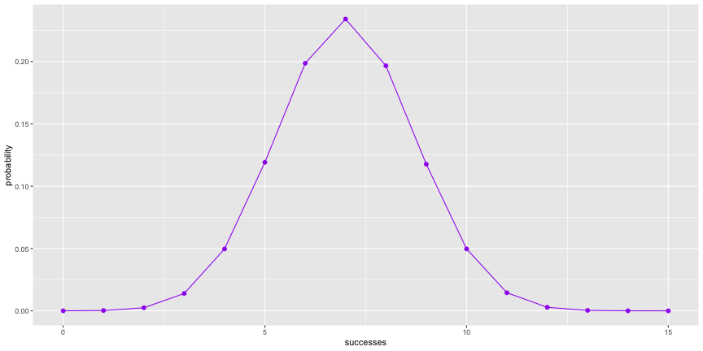

### Hypergeometric distribution: code

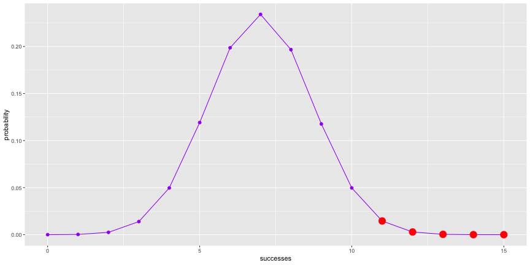

### Hypergeo example

- 100 marbles
- 20 are white
- Question: draw 10 (k), obtain 3 (q); **how likely is \( \geq 3 \)?**

### Hypergeo example

- 100 marbles
- 20 are white
- Question: draw 10 (k), obtain 3 (q); **how likely is \( \geq 3 \)?**

```r
phyper(2, 20, 80, 10, lower.tail = FALSE, log.p = FALSE)
```

```
[1] 0.3187799
```

```
lower.tail
logical; if TRUE (default), probabilities are P[X ≤ x], otherwise, P[X > x]
```

### Hypergeo example

- 100 marbles
- 20 are white
- Question: draw 10 (k), obtain 3 (q); **how likely is \( \geq 3 \)?**

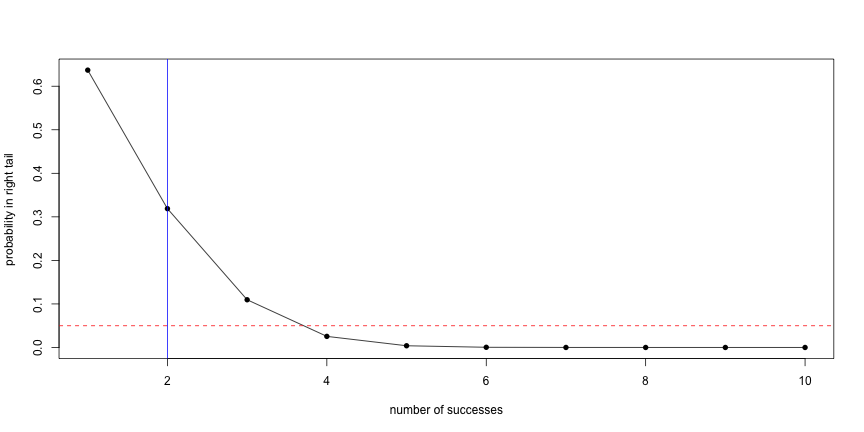

### Hypergeo example

- 100 marbles
- 20 are white
- draw 10 (k), obtain 3 (q); **how likely is *exactly* 3?**

```r
q = 0:10
probability = dhyper(x=q, m=20, n=80, k=10)
plot(q, probability, xlab = "number of successes", ylab = "probability in right tail", pch=16)
lines(q, probability)
abline(h = 0.05, lty = 2, col = 'red')
abline(v = 3, col = 'blue')
```

### Hypergeo example

- 100 marbles
- 20 are white
- draw 10 (k), obtain 3 (q); **how likely is *exactly* 3?**

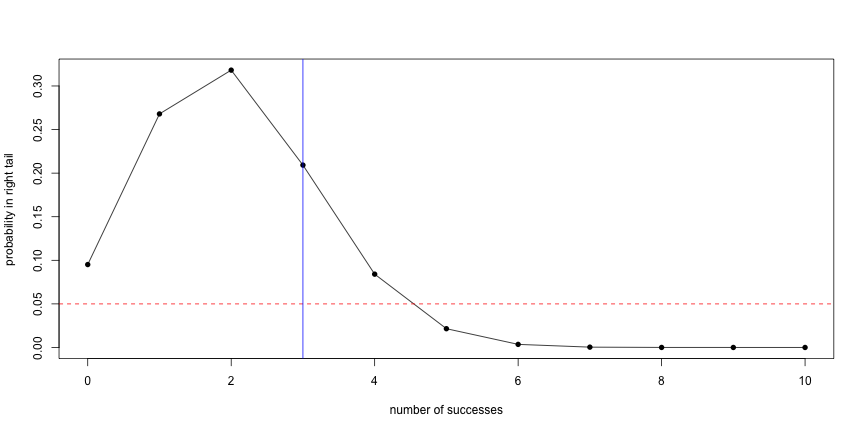

```
[1] 0.209
```

### Hypergeometric distribution 1-tailed

# [Fisher's exact test](https://en.wikipedia.org/wiki/Fisher%27s_exact_test)

### What about general enrichment problems?

- large populations >> k, \( p \)=very small
- background available

### What about general enrichment problems?

- use math to estimate uncertainty
- aside: if probabilities known: use \( \chi ^2 \) test!

### What about general enrichment problems?

- use math to estimate uncertainty
- aside: if probabilities known: use \( \chi ^2 \) test!
- true probability not known: Bayes to the rescue

### What about general enrichment problems?

suppose we have 2 sets of observations:

- one is **control** condition
- one is **treatment** condition
- each observation is a “draw” as in hypergeo, but now

### What about general enrichment problems?

suppose we have 2 sets of observations:

- one is **control** condition
- one is **treatment** condition
- each observation is a “draw” as in hypergeo, but now

### sample with replacement

### population unknown in both cases

### General Enrichment Calculation

What is the probability of finding a read in a given gene (random draw), given the data

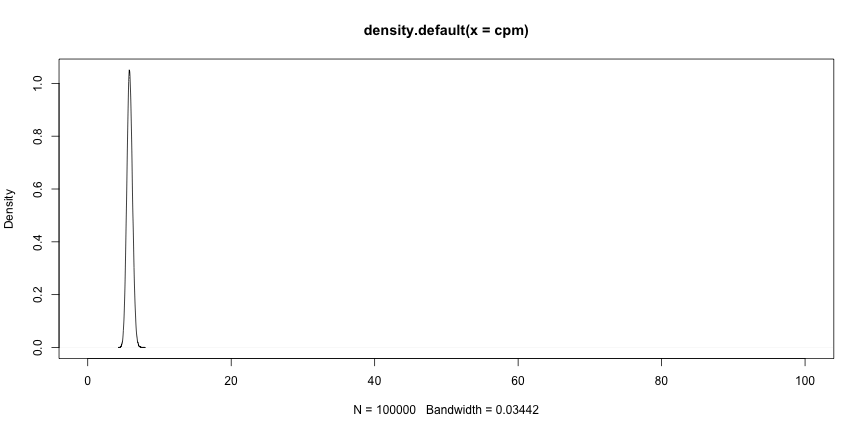

```
[1] "5.9 cpm"
```

```r
credible_expression <- rbeta(1e5, 234, 4e7)
cpm <- credible_expression * 1e6
plot(density(cpm), xlim=c(0,100))
```

### General Enrichment Calculation

Splicing: splice forms A and B

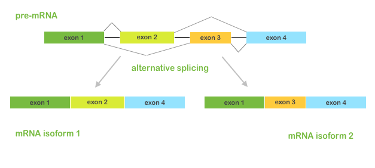

### General Enrichment Calculation

Splicing: splice forms A and B

Controls: A:B = 48:186

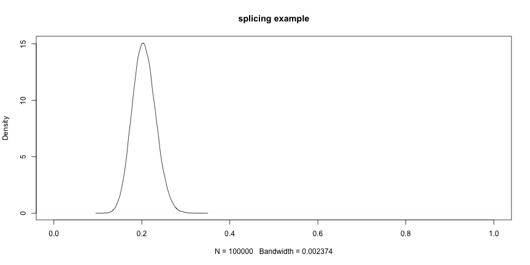

```
[1] 0.205
```

```r
# probability of observing form A in controls
plot(density(rbeta(1e5, 48, 186)), xlim=c(0,1), main="splicing example")
```

### General Enrichment Calculation

New Condition: observe 24 A, 47 B

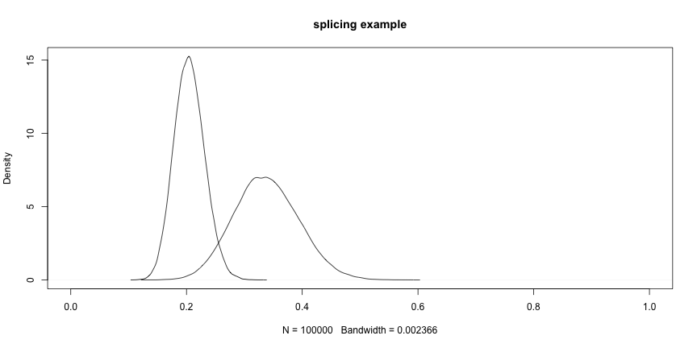

```r
# probability of observing form A in controls
plot(density(rbeta(1e5, 48, 186)), xlim=c(0,1), main="splicing example")
lines(density(rbeta(1e5, 24, 47)))
```

### General Enrichment Calculation

New Condition: observe 24 A, 47 B

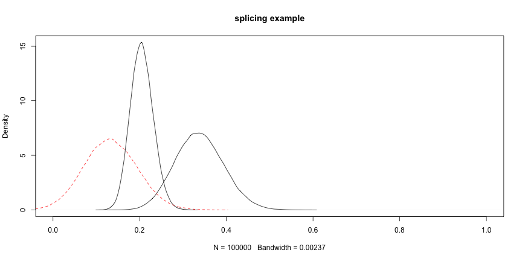

```r
# probability of observing form A in controls
plot(density(rbeta(1e5, 48, 186)), xlim=c(0,1), main="splicing example")
lines(density(rbeta(1e5, 24, 47)))
lines(density(rbeta(1e5, 24, 47)-rbeta(1e5, 48, 186)), lty=2, col='red')
```

### General Enrichment Calculation

**“Null”** hypothesis test: rejection!

```r
nsamples <- 1e6
treatment <- rbeta(nsamples, 24, 47)
control <- rbeta(nsamples, 48, 186)
p_value <- sum(treatment - control <= 0) / nsamples
print(p_value)
```

```
[1] 0.012785
```

### General Enrichment Calculation: Applications

- splicing

### General Enrichment Calculation: Applications

- splicing
- enrichment of SNPs in epigenomics data

### General Enrichment Calculation: Applications

- splicing
- enrichment of SNPs in epigenomics data
- allele specific expression (ASE)

### General Enrichment Calculation: Applications

### Any problem involving count data where the underlying probability is not known but a suitable “background” condition is available for comparison